# Bayesian analysis template

[anonymized for review]

*Template 4:*

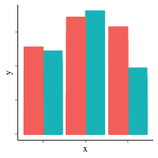

**Interaction of two categorical independent variables (bar chart)**

## Introduction

Welcome! This template will guide you through a Bayesian analysis in R, even if you have never done Bayesian analysis before. There are a set of templates, each for a different type of analysis. This template is for data with **two interacting categorical independent variables** and will produce a **bar chart**. If your analysis includes a **two-way ANOVA**, this might be the right template for you.

This template assumes you have basic familiarity with R. Once complete, this template will produce a summary of the analysis, complete with parameter estimates and credible intervals, and two animated HOPs (see Hullman, Resnick, Adar 2015 DOI: 10.1371/journal.pone.0142444 and Kale, Nguyen, Kay, and Hullman VIS 2018 for more information) for both your prior and posterior estimates.

This Bayesian analysis focuses on producing results in a form that are easily interpretable, even to nonexperts. The credible intervals produced by Bayesian analysis are the analogue of confidence intervals in traditional null hypothesis significance testing (NHST). A weakness of NHST confidence intervals is that they are easily misinterpreted. Many people naturally interpret an NHST 95% confidence interval to mean that there is a 95% chance that the true parameter value lies somewhere in that interval; in fact, it means that if the experiment were repeated 100 times, 95 of the resulting confidence intervals would include the true parameter value. The Bayesian credible interval sidesteps this complication by providing the intuitive meaning: a 95% chance that the true parameter value lies somewhere in that interval. To further support intuitive interpretations of your results, this template also produces animated HOPs, a type of plot that is more effective than visualizations such as error bars in helping people make accurate judgments about probability distributions.

This set of templates supports a few types of statistical analysis. (In future work, this list of supported statistical analyses will be expanded.) For clarity, each type has been broken out into a separate template, so be sure to select the right template before you start! A productive way to choose which template to use is to think about what type of chart you would like to produce to summarize your data. Currently, the templates support the following:

*One independent variable:*

1. Categorical; bar graph (e.g. t-tests, one-way ANOVA)
2. Ordinal; line graph (e.g. t-tests, one-way ANOVA)
3. Continuous; line graph (e.g. linear regression)

*Two interacting independent variables:*

4. **Two categorical; bar graph (e.g. two-way ANOVA)**
5. One categorical, one ordinal; line graph (e.g. two-way ANOVA)
6. One categorical, one continuous; line graph (e.g. linear regression with multiple lines)

Note that this template fits your data to a model that assumes normally distributed error terms. (This is the same assumption underlying t-tests, ANOVA, etc.) This template requires you to have already run diagnostics to determine that your data is consistent with this assumption; if you have not, the results may not be valid.

Once you have selected your template, to complete the analysis, please follow along this template. For each code chunk, you may need to make changes to customize the code for your own analysis. In those places, the code chunk will be preceded by a list of things you need to change (with the heading “What to change”), and each line that needs to be customized will also include the comment `#CHANGE ME` within the code chunk itself. You can run each code chunk independently during debugging; when you’re finished, you can knit the document to produce the complete document.

Good luck!

### Sample dataset

This template comes prefilled with an example dataset from Moser et al. (DOI: 10.1145/3025453.3025778), which examines choice overload in the context of e-commerce. The study examined the relationship between choice satisfaction (measured at a 7-point Likert scale), the number of product choices presented on a webpage, and whether the participant is a decision “maximizer” (a person who examines all options and tries to choose the best) or a “satisficer” (a person who selects the first option that is satisfactory). In this template, we analyze the relationship between choice set size, which we treat as an (ordinal) categorical variable in this template with possible values [12,24,40,50,60,72]; type of decision-making (maximizer or satisficer), a two-level categorical variable; and choice satisfaction, which we treat as a continuous variable with values that can fall in the range [1,7].

## Set up

### Requirements

To run this template, we assume that you are using RStudio, and you have the most recent version of R installed. (This template was built with R version 3.5.1.)

This template works best if you first open the file `bayesian-template.Rproj` from the code repository as a project in RStudio to get started, and then open the individual `.Rmd` template files after this.

### Libraries

**Installation:** If this is your first time using the template, you may need to install libraries.

1. **If you are using Windows,** first you will need to manually install RStan and Rtools. Follow the instructions [here](https://github.com/stan-dev/rstan/wiki/Installing-RStan-on-Windows) to install both.
2. On both Mac and Windows, uncomment the lines below - `install.packages()` and `devtools::install_github()` - to install the required packages. This only needs to be done once.

**Troubleshooting:** You may have some trouble installing the packages, especially if you are on Windows. Regardless of OS, if you have any issues installing these packages, try one or more of the following troubleshooting options:

1. Restart R. This is especially important after you install `devtools`, which requires a restart to work properly.
2. Make sure you are running the most recent version of R (3.5.1, as of the writing of this template).
3. Manually install RStan and Rtools, following the instructions [here](https://github.com/stan-dev/rstan/wiki/RStan-Getting-Started).
4. If you have tried the above and you are still getting error messages like `there is no package called [X]`, try installing the missing package(s) manually using the RStudio interface under Tools > Install Packages…

```r
knitr::opts_chunk$set(fig.align="center")

# install.packages(c("ggplot2", "rstanarm", "tidyverse", "tidybayes", "modelr", "devtools"))
# devtools::install_github("thomasp85/gganimate")

library(rstanarm) #bayesian analysis package
library(tidyverse) #tidy datascience commands
library(tidybayes) #tidy data + ggplot workflow
library(modelr) #tidy pipelines for modeling
library(ggplot2) #plotting package
library(gganimate) #animate ggplots

theme_set(theme_light()) # set the ggplot theme for all plots
```

### Read in data

**What to change**

1. mydata: Read in your data.

```r
mydata = read.csv('datasets/choc_cleaned_data.csv') #CHANGE ME 1
```

## Set model

We’ll fit the following model: `stan_glm(y ~ x1 * x2)`, where both $x_1$ and $x_2$ are categorical variables. This specifies a linear regression with dummy variables for each level in $x_1$ and $x_2$, plus interaction terms for each combination of $x_1$ and $x_2$. **This is equivalent to ANOVA.** So for example, for a regression where $x_1$ has three levels and $x_2$ has two levels, each $y_i$ is drawn from a normal distribution with mean equal to $a + b*dummy$ (where $b*dummy$ is the appropriate dummy term) and standard deviation equal to `sigma` ($\sigma$):

$$\begin{aligned}
y_i \sim Normal(a + b_{x1a}dummy_{x1a} + b_{x1b}dummy_{x1b} + \\
b_{x2}dummy_{x2} + \\
b_{x2}dummy_{x2} * b_{x1a}dummy_{x1a} + \\
b_{x2}dummy_{x2} * b_{x1b}dummy_{x1b}, \\\sigma)
\end{aligned}$$

Choose your independent and dependent variables. These are the variables that will correspond to the x and y axis on the final plots.

**What to change**

2. mydata$x1: Select which variables will appear on the x-axis of your plots.
3. mydata$x2: Select the second independent variable. Each level of this variable will correspond to a different bar color in the output plot.
4. mydata$y: Select which variables will appear on the y-axis of your plots.
5. x_lab: Label your plots’ x-axes.
6. y_lab: Label your plots’ y-axes.

```r
#select your independent and dependent variables
mydata$x1 = as.factor(mydata$num_products_displayed) #CHANGE ME 2
mydata$x2 = mydata$sat_max #CHANGE ME 3
mydata$y = mydata$satis_Q1 #CHANGE ME 4

# label the axes on the plots
x_lab = "Choices" #CHANGE ME 5
y_lab = "Satisfaction" #CHANGE ME 6
```